# Text Analysis and Modelling

#Brief

For this exercise I am working with Jane Austen data, data from the package hcandersenr (this has the text of Hans Christian Andersen fairy tales), and data from the package languageR (this has the text of “Alice in Wonderland”). I’ll also be using a dataset of movie reviews from the text2vec package.

I will be:

1. Creating a word cloud of the top words that appear in the book “The Little Mermaid”.
2. Making a bar chart showing the top 10 most frequent sentiment words in “The Little Mermaid”. Making the length of the bars depend on how often the words are said, and making the colour of the bars depend on the sentiment of the word.
3. Finding the most common bigrams in “Alice in Wonderland” that start with “very” followed by a sentiment word from the “bing” sentiment list.
4. Using TF-IDF scores to find the 5 words most associated with the three sets of books looked at so far (Hans Christian Andersen stories, Jane Austen’s novels, and Lewis Carroll’s “Alice in Wonderland”).
5. Creating an appropriate regression model that predicts sentiment using the word dummies and identifying which words are important for predicting sentiment in the movie review data set.
6. Creating sentiment arcs that show how the sentiment changes though the following Hans Christian Andersen stories:

“The Little Mermaid” “Thumbelina” “The Snow Queen” “The Ugly Duckling” “The Princess and the Pea”

## Preparation

```r
library(tidyverse)
library(tidytext)
library(ggwordcloud)
library(janeaustenr)
```

```r
library(hcandersenr)
hcandersen_en
```

| text | book |
| --- | --- |
| A soldier came marching along the high road: "Left, right - left, right." He | The tinder-box |
| had his knapsack on his back, and a sword at his side; he had been to the wars, | The tinder-box |
| and was now returning home. As he walked on, he met a very frightful-looking old | The tinder-box |
| witch in the road. Her under-lip hung quite down on her breast, and she stopped | The tinder-box |
| and said, "Good evening, soldier; you have a very fine sword, and a large | The tinder-box |
| knapsack, and you are a real soldier; so you shall have as much money as ever | The tinder-box |
| you like." | The tinder-box |
| "Thank you, old witch," said the soldier. | The tinder-box |
| "Do you see that large tree," said the witch, pointing to a tree which stood | The tinder-box |
| beside them. "Well, it is quite hollow inside, and you must climb to the top, | The tinder-box |

[output cut: 990 more lines]

```r
library(languageR)
head(alice, 20)
```

```
 [1] "ALICE"       "S"           "ADVENTURES"  "IN"          "WONDERLAND"  "Lewis"       "Carroll"     "THE"         "MILLENNIUM"  "FULCRUM"     "EDITION"
[12] "3"           "0"           "CHAPTER"     "I"           "Down"        "the"         "Rabbit-Hole" "Alice"       "was"
```

```r
alice_book_words <- tibble(book = 'Alice in Wonderland', text = alice)
```

```r
alice_book_collapsed <- tibble(book = 'Alice in Wonderland',
                               text = str_c(alice, collapse = ' '))
```

```r
library(text2vec)
glimpse(movie_review)
```

```
Rows: 5,000
Columns: 3
$ id        <chr> "5814_8", "2381_9", "7759_3", "3630_4", "9495_8", "8196_8", "7166_2", "10633_1", "319_1", "8713_10", "2486_3", "6811_10", "11744_9", "7369_…
$ sentiment <int> 1, 1, 0, 0, 1, 1, 0, 0, 0, 1, 0, 1, 1, 0, 0, 0, 0, 0, 1, 1, 1, 1, 1, 0, 0, 1, 0, 0, 0, 0, 0, 1, 1, 1, 0, 0, 1, 0, 1, 0, 1, 0, 1, 0, 0, 1, 0…
$ review    <chr> "With all this stuff going down at the moment with MJ i've started listening to his music, watching the odd documentary here and there, wat…
```

1. Creating a word cloud of the top words that appear in the book “The Little Mermaid”.

```r
little_mermaid_words <- hcandersen_en %>%
  filter(book == "The little mermaid") %>%
  unnest_tokens(word, text) %>%
  count(word, sort = TRUE) %>%
  anti_join(stop_words)
```

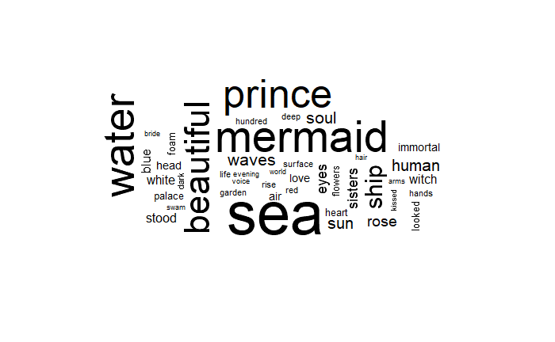

```r
ggwordcloud(
  words = little_mermaid_words$word,
  freq = little_mermaid_words$n,
  min.freq = 10
)
```

2. Making a bar chart showing the top 10 most frequent sentiment words in “The Little Mermaid”. Making the length of the bars depend on how often the words are said, and making the colour of the bars depend on the sentiment of the word.

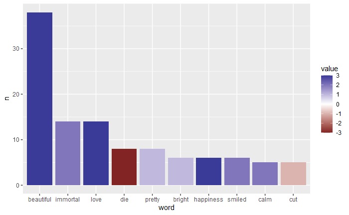

```r
little_mermaid_words %>%
  inner_join(get_sentiments("afinn")) %>%
  slice(1:10) %>%
  mutate(word = factor(word, levels = word)) %>%
  ggplot() +
  aes(x = word, y = n, fill = value) +
  geom_col() +
  scale_fill_gradient2()
```

3. Finding the most common bigrams in “Alice in Wonderland” that start with “very” followed by a sentiment word from the “bing” sentiment list.

```r
alice_bigrams <-
alice_book_collapsed %>%
unnest_tokens(bigram, text, token = "ngrams", n = 2) %>%
separate(bigram, c("word_1", "word_2"), sep = " ")
```

```r
alice_bigrams
```

| book | word_1 | word_2 |
| --- | --- | --- |
| Alice in Wonderland | alice | s |
| Alice in Wonderland | s | adventures |
| Alice in Wonderland | adventures | in |
| Alice in Wonderland | in | wonderland |
| Alice in Wonderland | wonderland | lewis |
| Alice in Wonderland | lewis | carroll |
| Alice in Wonderland | carroll | the |
| Alice in Wonderland | the | millennium |
| Alice in Wonderland | millennium | fulcrum |
| Alice in Wonderland | fulcrum | edition |

[output cut: 990 more lines]

```r
alice_bigrams %>%
  inner_join(get_sentiments("bing"), by = c("word_2" = "word")) %>%
  filter(word_1 == "very") %>%
  count(word_1, word_2, sentiment, sort = TRUE)
```

| word_1 | word_2 | sentiment | n |
| --- | --- | --- | --- |
| very | glad | positive | 5 |
| very | good | positive | 4 |
| very | tired | negative | 3 |
| very | uncomfortable | negative | 3 |
| very | well | positive | 3 |
| very | angrily | negative | 2 |
| very | difficult | negative | 2 |
| very | earnestly | positive | 2 |
| very | gravely | negative | 2 |
| very | interesting | positive | 2 |

[output cut: 34 more lines]

4. Using TF-IDF scores to find the 5 words most associated with the three sets of books looked at so far (Hans Christian Andersen stories, Jane Austen’s novels, and Lewis Carroll’s “Alice in Wonderland”).

```r
compare <- bind_rows(
  austen = austen_books(),
  anderson = hcandersen_en,
  carroll = alice_book_words,
  .id = 'author'
)
```

```r
compare %>%
  unnest_tokens(word, text) %>%
  count(author, word) %>%
  bind_tf_idf(word, author, n) %>%
  arrange(author, desc(tf_idf)) %>%
  group_by(author) %>%
  slice(1:5)
```

| author | word | n | tf | idf | tf_idf |
| --- | --- | --- | --- | --- | --- |
| anderson | princess | 217 | 0.0005212449 | 1.0986123 | 0.0005726461 |
| anderson | rudy | 194 | 0.0004659978 | 1.0986123 | 0.0005119509 |
| anderson | mother | 458 | 0.0011001391 | 0.4054651 | 0.0004460680 |
| anderson | stork | 137 | 0.0003290809 | 1.0986123 | 0.0003615323 |
| anderson | gerda | 114 | 0.0002738337 | 1.0986123 | 0.0003008371 |
| austen | mr | 3015 | 0.0041583052 | 0.4054651 | 0.0016860477 |
| austen | mrs | 2446 | 0.0033735372 | 0.4054651 | 0.0013678516 |
| austen | fanny | 862 | 0.0011888753 | 1.0986123 | 0.0013061130 |
| austen | emma | 787 | 0.0010854349 | 1.0986123 | 0.0011924721 |
| austen | elinor | 623 | 0.0008592452 | 1.0986123 | 0.0009439773 |

[output cut: 5 more lines]

5. Creating an appropriate regression model that predicts sentiment using the word dummies and identifying which words are important for predicting sentiment in the movie review data set.

```r
reviews  <-
movie_review %>%
  unnest_tokens(word, review) %>%
  as_tibble() %>%
  anti_join(stop_words)
```

```r
top_50 <-
reviews %>%
  count(word, sort = TRUE) %>%
  top_n(50)
```

```r
reviews <-
reviews %>%
  inner_join(top_50)
reviews <-
  reviews %>%
  distinct(id, word, .keep_all = TRUE) %>%
  mutate(present = 1) %>%
  spread(word, present, fill = 0) %>%
  select(-id, -n)
```

```r
model <- glm(sentiment ~ ., data = reviews, family = binomial(link = "logit"))
```

```r
broom::tidy(model) %>%
  arrange(p.value)
```

| term | estimate | std.error | statistic | p.value |
| --- | --- | --- | --- | --- |
| worst | -2.242469775 | 0.2337169 | -9.594810311 | 8.407160e-22 |
| bad | -1.135179809 | 0.1873057 | -6.060571312 | 1.356389e-09 |
| minutes | -0.857100934 | 0.2012263 | -4.259388423 | 2.049870e-05 |
| script | -0.740905474 | 0.1974416 | -3.752529920 | 1.750589e-04 |
| plot | -0.576550932 | 0.1864239 | -3.092687666 | 1.983528e-03 |
| family | 0.609554402 | 0.2024043 | 3.011568771 | 2.599015e-03 |
| guy | -0.546512252 | 0.1816808 | -3.008090489 | 2.628948e-03 |
| love | 0.507642382 | 0.1877107 | 2.704387090 | 6.843052e-03 |
| horror | -0.544259427 | 0.2020413 | -2.693802838 | 7.064194e-03 |
| acting | -0.484840053 | 0.1857575 | -2.610069688 | 9.052378e-03 |

[output cut: 41 more lines]

6. Creating sentiment arcs that show how the sentiment changes though the following Hans Christian Andersen stories:

“The Little Mermaid” “Thumbelina” “The Snow Queen” “The Ugly Duckling” “The Princess and the Pea”

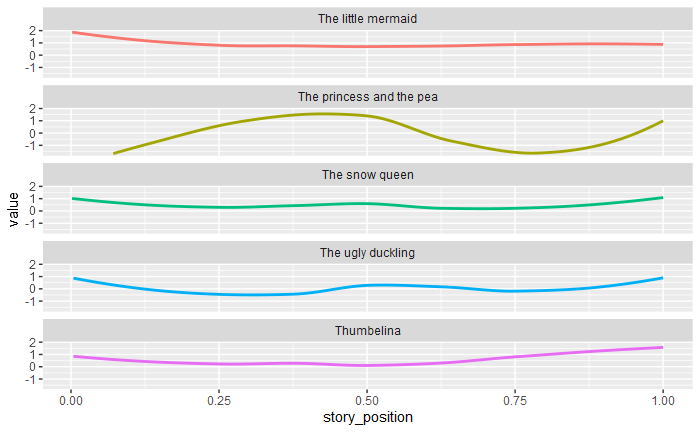

```r
hcandersen_en %>%
  filter(book %in% c("The little mermaid", "Thumbelina", "The snow queen", "The ugly duckling", "The princess and the pea")) %>%
  unnest_tokens(word, text) %>%
  inner_join(get_sentiments("afinn")) %>%
  group_by(book) %>%
  mutate(
    word_n = row_number()
  ) %>%
  mutate(
    story_position = word_n/max(word_n) # all books on scale from 0 to 1
  ) %>%
ggplot +
  aes(x = story_position, y = value, colour = book) +
  geom_smooth(se = FALSE) +
  guides(colour = FALSE) +
  facet_wrap(~book, nrow = 5)
```